# Project: Stroke Prediction Model

## Purpose

The purpose of this project is to create a stroke prediction machine learning model to predict the likelihood that a person will experience a stroke based on their health and their lifestyle.

This enables early intervention, preventive care, and better resource allocation in healthcare.

The main goals are:

- Risk Assessment - Identify individuals at high risk of stroke before symptoms occur
- Action - Help doctors recommend lifestyle changes, medication, or monitoring to reduce stroke risk.
- Early Diagnosis - Assist general practitioners and screening programs in prioritizing patients
- Personalized Care - Provide patient-specific insights based on predictive features (e.g., glucose levels, age).
- Cost reduction - Lower long-term healthcare costs by preventing severe complications through early detection.

## ROI

The return of investment meant to be achieved is

- Reduced Hospitalizations - Early detection reduces emergency admissions, ICU stays, and long-term care costs.
- Lower Treatment Costs - Preventive treatment is cheaper than managing stroke aftermath (e.g., rehab, surgery).
- Faster Response Time - High-risk patients are flagged earlier, leading to faster diagnosis and fewer complications.
- Decreased Readmission Rates - Monitoring and follow-up for high-risk patients improves outcomes and reduces return visits.
- Optimized Resource Allocation - Healthcare systems can focus on the most vulnerable patients, improving efficiency.

# Projects development

### Import Libraries

First I need to install the libraries that I not have in my environment.

I have anaconda so I used this command:

pip install pandas numpy matplotlib seaborn scikit-learn xgboost

Once done I import libraries for data manipulation, visualization, and model training

# not an active part of code. just to show what you need to install in your anaconda env before importing the libraries # open your terminal and digit the below code pip install pandas numpy matplotlib seaborn scikit-learn xgboost

```python
import pandas as pd
import numpy as np
import matplotlib.pyplot as plt
import seaborn as sns
from sklearn.model_selection import train_test_split
from sklearn.preprocessing import StandardScaler, LabelEncoder
from sklearn.ensemble import RandomForestClassifier, GradientBoostingClassifier
from sklearn.metrics import accuracy_score, confusion_matrix, classification_report, ConfusionMatrixDisplay, roc_auc_score, RocCurveDisplay
from imblearn.over_sampling import SMOTE
from sklearn.model_selection import cross_val_score
from imblearn.ensemble import BalancedRandomForestClassifier
from sklearn.linear_model import LogisticRegression
from sklearn.pipeline import make_pipeline
from sklearn.svm import SVC
from xgboost import XGBClassifier
from sklearn.model_selection import RandomizedSearchCV
```

```python
import warnings
warnings.filterwarnings(action ='ignore')
```

### Load Dataset

I load the dataset that I previously uploaded in my project jupyter lab

From the preview of the dataset I can see that not all variables are numerical, and the bmi contains null values

```python
# Load dataset
df = pd.read_csv('stroke_data.csv')

# Display first rows
df.head()
```

|  | id | gender | age | hypertension | heart_disease | ever_married | work_type | Residence_type | avg_glucose_level | bmi | smoking_status | stroke |
| --- | --- | --- | --- | --- | --- | --- | --- | --- | --- | --- | --- | --- |
| 0 | 9046 | Male | 67.0 | 0 | 1 | Yes | Private | Urban | 228.69 | 36.6 | formerly smoked | 1 |
| 1 | 51676 | Female | 61.0 | 0 | 0 | Yes | Self-employed | Rural | 202.21 | NaN | never smoked | 1 |
| 2 | 31112 | Male | 80.0 | 0 | 1 | Yes | Private | Rural | 105.92 | 32.5 | never smoked | 1 |
| 3 | 60182 | Female | 49.0 | 0 | 0 | Yes | Private | Urban | 171.23 | 34.4 | smokes | 1 |
| 4 | 1665 | Female | 79.0 | 1 | 0 | Yes | Self-employed | Rural | 174.12 | 24.0 | never smoked | 1 |

# Data Preprocessing

Having seen BMI variable with null values I would like to check how many features contains nulls and how many per each of them.

Also I would like to check the data type and some statistics overview

I can see that the variable bmi has many missing values. I need to decide if drop the rows with missing values or if interpolate using the mean

In regard to the statistical part, I can see that:

- The age standard deviation of ~ 22.6 suggest a good variability of the population selected for this study. In fact the min age is 0.08 and the max is 82 years old
- Hypertension and hearth desease is not often remarked in this selected population
- Avg glucose level ranges indicate the presence of both normal and diabetic individuals
- BMI mean is ~28.9 (overweight category). Max value of 97.6 is suspiciously high. This is needed to be handled.
- stroke (our target variable) is "fortunately" only 4.87 % of the cases.

The stroke rarity suggest a strong class imbalance, which justifies using SMOTE or similar techniques (that we will see later in this project, during the modelling phase)

```python
#basic dataset info
df.info()  # Data types and missing values
df.describe()  # Statistical summary of numerical features
```

```
<class 'pandas.core.frame.DataFrame'>
RangeIndex: 5110 entries, 0 to 5109
Data columns (total 12 columns):
 #   Column             Non-Null Count  Dtype
---  ------             --------------  -----
 0   id                 5110 non-null   int64
 1   gender             5110 non-null   object
 2   age                5110 non-null   float64
 3   hypertension       5110 non-null   int64
 4   heart_disease      5110 non-null   int64
 5   ever_married       5110 non-null   object
 6   work_type          5110 non-null   object
 7   Residence_type     5110 non-null   object
 8   avg_glucose_level  5110 non-null   float64
 9   bmi                4909 non-null   float64
 10  smoking_status     5110 non-null   object
 11  stroke             5110 non-null   int64
dtypes: float64(3), int64(4), object(5)
memory usage: 479.2+ KB
```

|  | id | age | hypertension | heart_disease | avg_glucose_level | bmi | stroke |
| --- | --- | --- | --- | --- | --- | --- | --- |
| count | 5110.000000 | 5110.000000 | 5110.000000 | 5110.000000 | 5110.000000 | 4909.000000 | 5110.000000 |
| mean | 36517.829354 | 43.226614 | 0.097456 | 0.054012 | 106.147677 | 28.893237 | 0.048728 |
| std | 21161.721625 | 22.612647 | 0.296607 | 0.226063 | 45.283560 | 7.854067 | 0.215320 |
| min | 67.000000 | 0.080000 | 0.000000 | 0.000000 | 55.120000 | 10.300000 | 0.000000 |
| 25% | 17741.250000 | 25.000000 | 0.000000 | 0.000000 | 77.245000 | 23.500000 | 0.000000 |
| 50% | 36932.000000 | 45.000000 | 0.000000 | 0.000000 | 91.885000 | 28.100000 | 0.000000 |
| 75% | 54682.000000 | 61.000000 | 0.000000 | 0.000000 | 114.090000 | 33.100000 | 0.000000 |
| max | 72940.000000 | 82.000000 | 1.000000 | 1.000000 | 271.740000 | 97.600000 | 1.000000 |

### Remark

Some research on internet showed that for clinical guidelines the BMI stops between 40 and 50.

However since in reality it is possible to find some patient with extreme high BMI but usually no more than 60 I would remove the lines with BMI more than 60 to be sure to not pollute the all dataset.

In fact these cases are possible but so rare than in most of the cases they are data entry errors.

```python
#First I count how many rows have BMI > 60
count_bmi_over_60 = df[df['bmi'] > 60].shape[0]
print("Number of people with BMI over 60:", count_bmi_over_60)
```

```
Number of people with BMI over 60: 13
```

```python
#Before removing the outliears I handle missing BMI values filling them with the median that is not impacted by the outliers
df['bmi'] = df['bmi'].fillna(df['bmi'].median())

#Then I remove the rows where BMI > 60
df = df[df['bmi'] <= 60]
```

Now I run again the basic dataset info to check how it is my dataset now.

I can see that the statistic are are only minimally impacted so no need to perform further checks.

```python
#basic cleaned dataset info
df.info()  # Data types and missing values
df.describe()  # Statistical summary of numerical features
```

```
<class 'pandas.core.frame.DataFrame'>
Index: 5097 entries, 0 to 5109
Data columns (total 12 columns):
 #   Column             Non-Null Count  Dtype
---  ------             --------------  -----
 0   id                 5097 non-null   int64
 1   gender             5097 non-null   object
 2   age                5097 non-null   float64
 3   hypertension       5097 non-null   int64
 4   heart_disease      5097 non-null   int64
 5   ever_married       5097 non-null   object
 6   work_type          5097 non-null   object
 7   Residence_type     5097 non-null   object
 8   avg_glucose_level  5097 non-null   float64
 9   bmi                5097 non-null   float64
 10  smoking_status     5097 non-null   object
 11  stroke             5097 non-null   int64
dtypes: float64(3), int64(4), object(5)
memory usage: 517.7+ KB
```

|  | id | age | hypertension | heart_disease | avg_glucose_level | bmi | stroke |
| --- | --- | --- | --- | --- | --- | --- | --- |
| count | 5097.000000 | 5097.000000 | 5097.000000 | 5097.000000 | 5097.000000 | 5097.000000 | 5097.000000 |
| mean | 36500.511674 | 43.229154 | 0.096724 | 0.054149 | 106.159892 | 28.758368 | 0.048852 |
| std | 21142.359849 | 22.629979 | 0.295610 | 0.226335 | 45.284811 | 7.406045 | 0.215580 |
| min | 67.000000 | 0.080000 | 0.000000 | 0.000000 | 55.120000 | 10.300000 | 0.000000 |
| 25% | 17740.000000 | 25.000000 | 0.000000 | 0.000000 | 77.280000 | 23.800000 | 0.000000 |
| 50% | 36901.000000 | 45.000000 | 0.000000 | 0.000000 | 91.890000 | 28.100000 | 0.000000 |
| 75% | 54590.000000 | 61.000000 | 0.000000 | 0.000000 | 114.090000 | 32.800000 | 0.000000 |
| max | 72940.000000 | 82.000000 | 1.000000 | 1.000000 | 271.740000 | 59.700000 | 1.000000 |

### Features Encoding

Now I need to convert categorical variables into integer because ML algorithms cannot process categories.

I decided to use label encoding for the ever_married since is binary and One-Hot for the others to avoid models misleading

```python
# Also decided to drop 'id' column (not useful)
df.drop('id', axis=1, inplace=True)

# Label encode 'ever_married'
le = LabelEncoder()
df['ever_married'] = le.fit_transform(df['ever_married'])

# One-Hot encode all multi-category features
df = pd.get_dummies(df, columns=['gender', 'work_type', 'Residence_type', 'smoking_status'])

# Check result
df.head()
```

|  | age | hypertension | heart_disease | ever_married | avg_glucose_level | bmi | stroke | gender_Female | gender_Male | gender_Other | ... | work_type_Never_worked | work_type_Private | work_type_Self-employed | work_type_children | Residence_type_Rural | Residence_type_Urban | smoking_status_Unknown | smoking_status_formerly smoked | smoking_status_never smoked | smoking_status_smokes |
| --- | --- | --- | --- | --- | --- | --- | --- | --- | --- | --- | --- | --- | --- | --- | --- | --- | --- | --- | --- | --- | --- |
| 0 | 67.0 | 0 | 1 | 1 | 228.69 | 36.6 | 1 | False | True | False | ... | False | True | False | False | False | True | False | True | False | False |
| 1 | 61.0 | 0 | 0 | 1 | 202.21 | 28.1 | 1 | True | False | False | ... | False | False | True | False | True | False | False | False | True | False |
| 2 | 80.0 | 0 | 1 | 1 | 105.92 | 32.5 | 1 | False | True | False | ... | False | True | False | False | True | False | False | False | True | False |
| 3 | 49.0 | 0 | 0 | 1 | 171.23 | 34.4 | 1 | True | False | False | ... | False | True | False | False | False | True | False | False | False | True |
| 4 | 79.0 | 1 | 0 | 1 | 174.12 | 24.0 | 1 | True | False | False | ... | False | False | True | False | True | False | False | False | True | False |

5 rows × 21 columns

```python
print(df.isnull().sum())
```

```
age                               0
hypertension                      0
heart_disease                     0
ever_married                      0
avg_glucose_level                 0
bmi                               0
stroke                            0
gender_Female                     0
gender_Male                       0
gender_Other                      0
work_type_Govt_job                0
work_type_Never_worked            0
work_type_Private                 0
work_type_Self-employed           0
work_type_children                0
Residence_type_Rural              0
Residence_type_Urban              0
smoking_status_Unknown            0
smoking_status_formerly smoked    0
smoking_status_never smoked       0
smoking_status_smokes             0
dtype: int64
```

# Exploratory Data Analysis

In this chapter I will examine and understand the dataset before building a model.

This helps to detect patterns, identify anomalies, and generate insights to guide preprocessing and for modeling decisions.

### Correlation Analysis

None of the variables show particularly strong correlations with stroke

The strongest correlations with stroke are:

- Age: 0.25 (weak positive)
- Heart_disease: 0.13 (very weak positive)
- Hypertension: 0.13 (very weak positive)
- Avg_glucose_level: 0.13 (very weak positive)

##### Deduction:

The relatively weak correlations suggest that no single variable is a strong predictor of stroke on its own.

Age appears to be the most correlated feature, indicating that stroke risk increases somewhat with age.

Health factors (heart_disease, hypertension, glucose level) show slight positive associations with stroke.

Therefore it is likely needed to use multiple features together to build an effective predictive model.

##### Point of attention on the smoker patients:

With surprise, smoking does not appear to have a strong correlation with stroke in this dataset. This might be because strokes are relatively rare among younger individuals, even those who smoke

Interestingly, there is a very weak correlation with former smokers, which could be explained by the fact that people often quit smoking as they age—possibly due to emerging health concerns. This further reinforces the observation that age is the most strongly correlated factor with stroke.

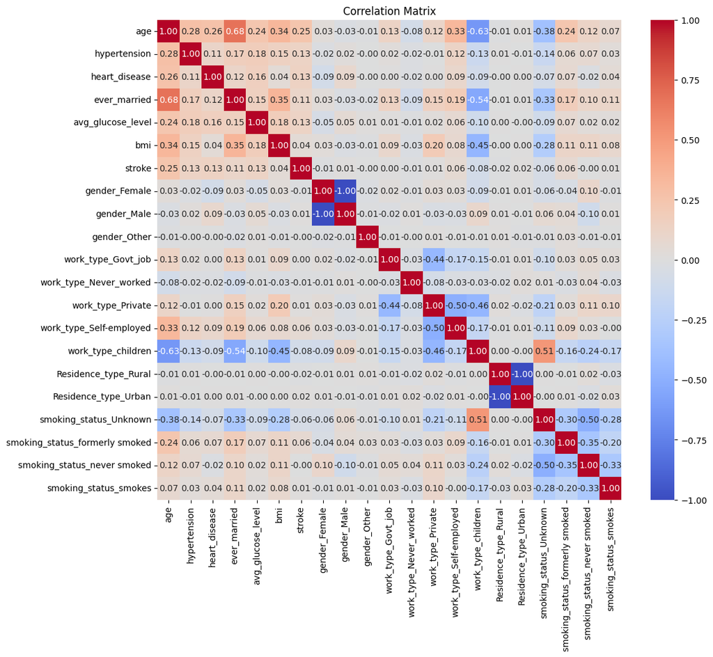

```python
# Correlation analysis
correlation_matrix = df.corr()
plt.figure(figsize=(12, 10))
sns.heatmap(correlation_matrix, annot=True, cmap='coolwarm', fmt=".2f")
plt.title("Correlation Matrix")
plt.show()
```

### Analysis of numerical variables

#### Age vs. Stroke:

As already mentioned above the age is the most incisive risk factor.

People who experienced strokes tend to be significantly older than those who didn't.

In fact the median age for stroke patients is 71 years old versus the no-stroke that is 43.

This supports the correlation value of 0.25 of above correlation matrix, confirming age is a relevant predictor

#### Average Glucose Level vs. Stroke:

People with strokes tend to have higher average glucose levels. The median glucose level appears slightly higher in the stroke group.

The stroke group shows wider variability in glucose levels. Some extreme high values appear in the non-stroke group (outliers).

This relationship appears stronger in the visualization than the 0.13 correlation suggested.

There is visible separation between the two groups' glucose distributions, particularly in their upper quartiles.

However due to weak correlation that we saw above, as a stroke predictor, avg_glucose_level provides some signal, but it's not a strong predictor on its own.

The boxplot that comes after, shows that while higher glucose tends to be associated with stroke, many people with high glucose don't have strokes, and some people with normal glucose do have strokes.

#### BMI vs. Stroke:

Surprisingly, BMI distributions look very similar between stroke and non-stroke groups.

Median BMI values are nearly identical between the two groups, that is around 28

The non-stroke group has more outliers with very high BMI values

This suggests BMI alone is a poor predictor of stroke

```python
# Calculate median age for stroke patients
median_age_stroke = df[df['stroke'] == 1]['age'].median()
print(f"Median age for stroke patients: {median_age_stroke}")
# Calculate median age for non stroke patients
median_age_no_stroke = df[df['stroke'] == 0]['age'].median()
print(f"Median age for no stroke patients: {median_age_no_stroke}")

# Calculate median avg glucose level for stroke patients
median_avg_glucose_level_stroke = df[df['stroke'] == 1]['avg_glucose_level'].median()
print(f"Median avg glucose level for stroke patients: {median_avg_glucose_level_stroke}")
# Calculate median avg glucose level for stroke patients
median_avg_glucose_level_no_stroke = df[df['stroke'] == 0]['avg_glucose_level'].median()
print(f"Median avg glucose level for no stroke patients: {median_avg_glucose_level_no_stroke}")

# Calculate median age for stroke patients
median_bmi_stroke = df[df['stroke'] == 1]['bmi'].median()
print(f"Median bmi for stroke patients: {median_bmi_stroke}")
# Calculate median age for non stroke patients
median_bmi_no_stroke = df[df['stroke'] == 0]['bmi'].median()
print(f"Median bmi for no stroke patients: {median_bmi_no_stroke}")
```

```
Median age for stroke patients: 71.0
Median age for no stroke patients: 43.0
Median avg glucose level for stroke patients: 105.22
Median avg glucose level for no stroke patients: 91.5
Median bmi for stroke patients: 28.1
Median bmi for no stroke patients: 28.1
```

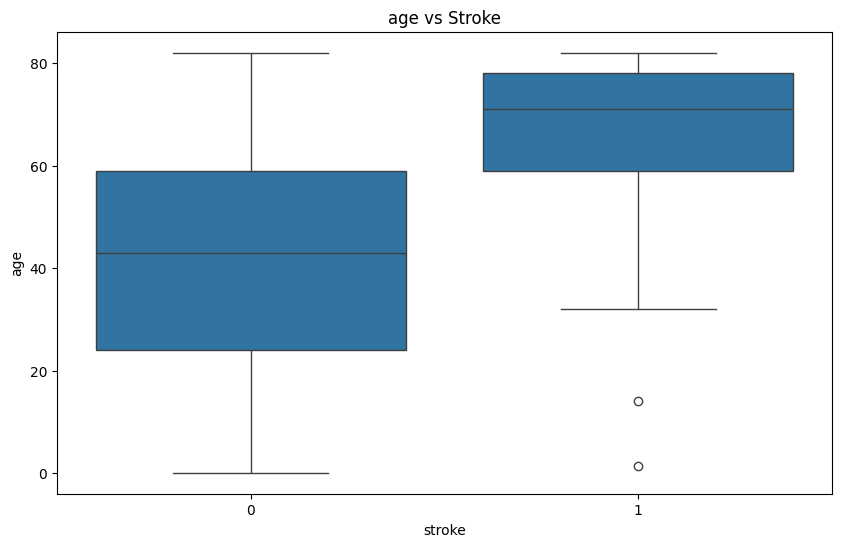

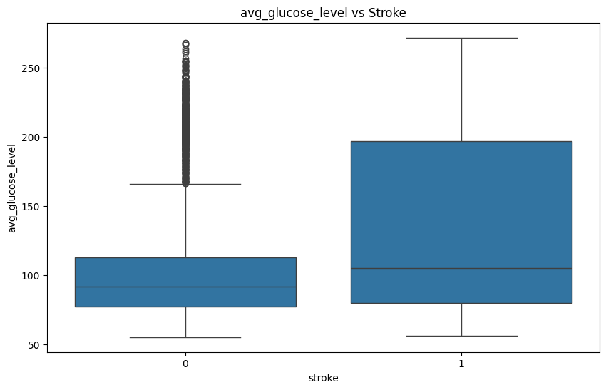

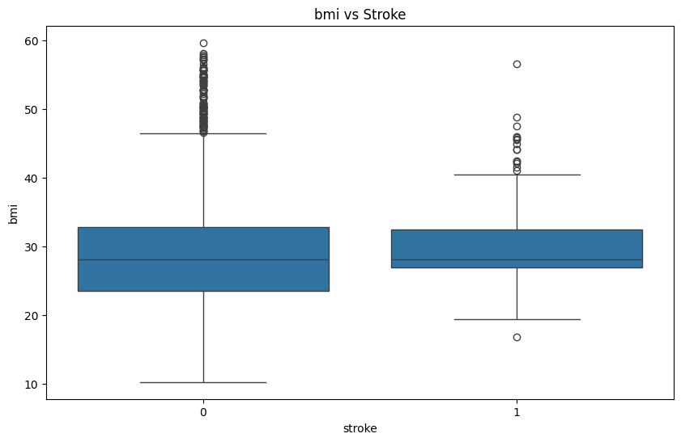

```python
# Explore relationships between key features and stroke
for col in ['age', 'avg_glucose_level', 'bmi']:
    plt.figure(figsize=(10, 6))
    sns.boxplot(x='stroke', y=col, data=df)
    plt.title(f'{col} vs Stroke')
    plt.show()
```

### Analysis of categorial variables

#### Hypertension vs Stroke

The proportion of patients with hypertension suffering from strokes is higher than the one with no hypertention.

This suggest that the hypertension is possible risk factor for stroke.

#### Heart Disease vs Stroke

Similar pattern to hypertension.

Those with heart disease have a higher percentage of stroke cases relative to their population.

This suggest that heart disease is also a possible predictive factor for stroke.

#### Gender vs Stroke

No evident difference in stroke occurrence by gender.

#### Smoker status vs Stroke

Proportionally, former smokers appear more likely to have experienced strokes compared to never-smokers

My thought on this point was already explained above.

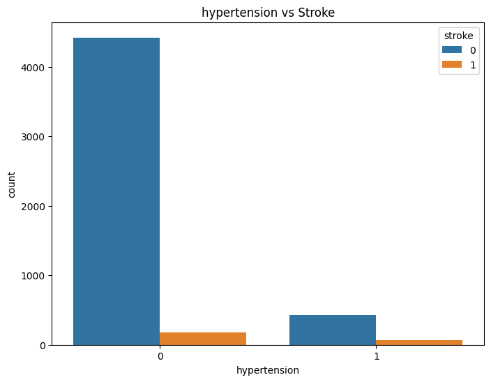

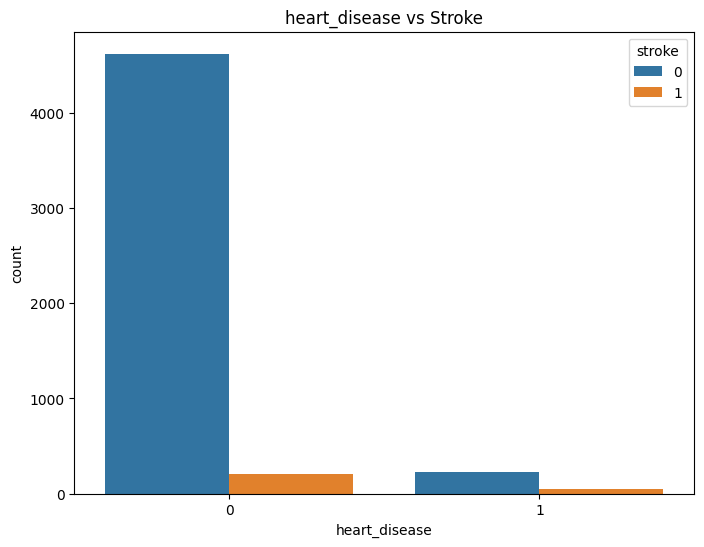

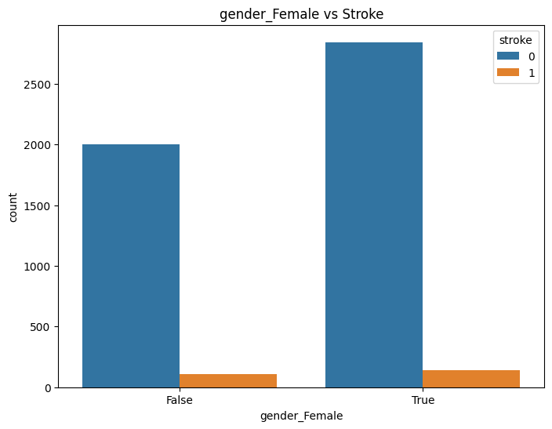

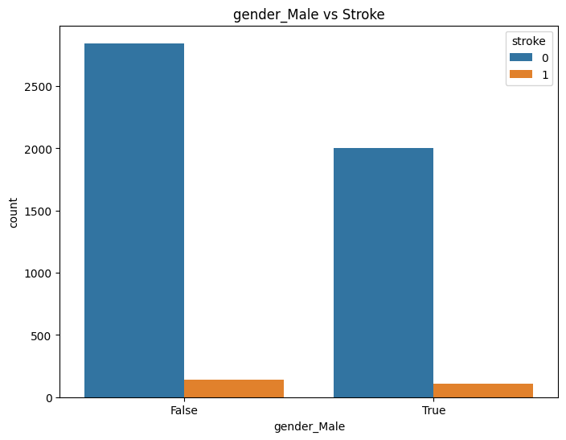

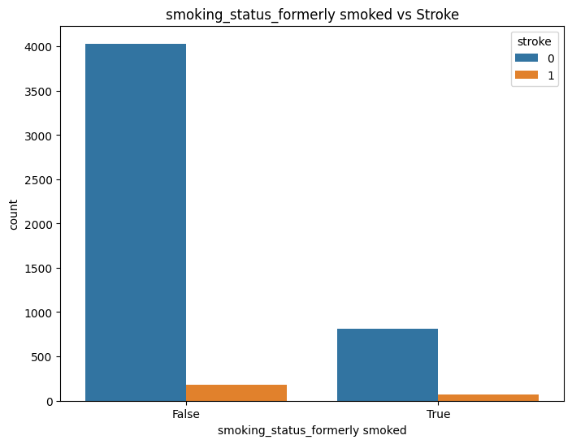

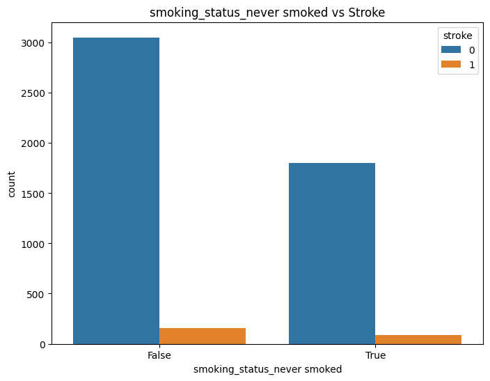

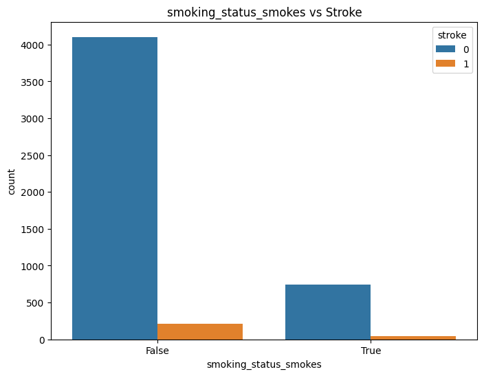

```python
# Analyze categorical variables
for col in ['hypertension', 'heart_disease', 'gender_Female', 'gender_Male',
           'smoking_status_formerly smoked', 'smoking_status_never smoked',
           'smoking_status_smokes']:
    plt.figure(figsize=(8, 6))
    sns.countplot(x=col, hue='stroke', data=df)
    plt.title(f'{col} vs Stroke')
    plt.show()
```

### Analysis by Age group

Once again we can see that the stronger risk factor for stroke is the age.

The stroke rate is exponetially increasing with the increase of age.

A slight higher rate can be noted in the Former smoker group.

```
Stroke rate (%) for Unknown by age group:
age_group
<30       0.233100
30-45     0.909091
45-60     5.479452
60+      12.757202
Name: stroke, dtype: float64
```

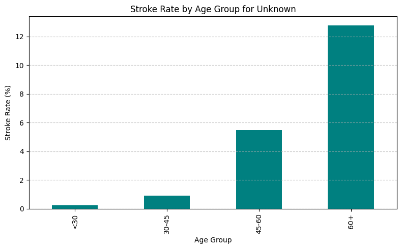

```
Stroke rate (%) for formerly smoked by age group:
age_group
<30       0.000000
30-45     1.898734
45-60     5.118110
60+      14.361702
Name: stroke, dtype: float64
```

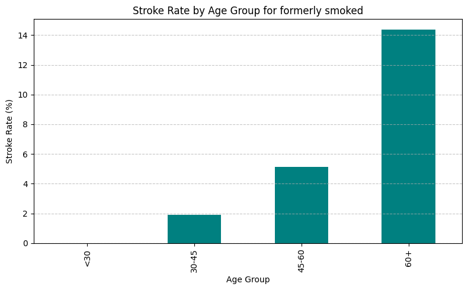

```
Stroke rate (%) for never smoked by age group:
age_group
<30       0.000000
30-45     0.672646
45-60     3.640257
60+      13.725490
Name: stroke, dtype: float64
```

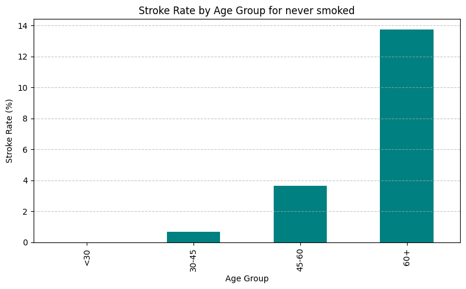

```
Stroke rate (%) for smokes by age group:
age_group
<30       0.000000
30-45     1.351351
45-60     7.024793
60+      12.643678
Name: stroke, dtype: float64
```

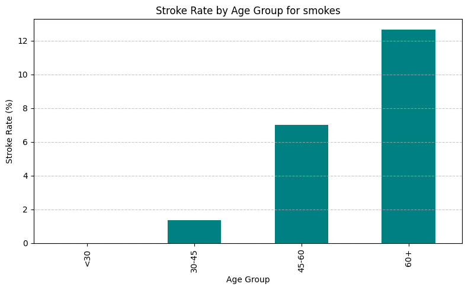

```python
# Create age groups
df_age_group = df.copy() #this is to not modify the original data frame that I will need all numerical

df_age_group['age_group'] = pd.cut(df_age_group['age'], bins=[0, 30, 45, 60, 100], labels=['<30', '30-45', '45-60', '60+'])

smoking_columns = [col for col in df_age_group.columns if col.startswith('smoking_status_')]


# For each smoking status, check stroke rate by age group
for smoking_col in smoking_columns:
    status_name = smoking_col.replace('smoking_status_', '')
    print(f"\nStroke rate (%) for {status_name} by age group:")

    # Filter for only people with this smoking status
    subset = df_age_group[df_age_group[smoking_col] == True]

    # Calculate and print stroke rate by age group
    stroke_by_age = subset.groupby('age_group', observed=True)['stroke'].mean() * 100
    print(stroke_by_age)

    # Visualize
    plt.figure(figsize=(8, 5))
    stroke_by_age.plot(kind='bar', color='teal')
    plt.title(f'Stroke Rate by Age Group for {status_name}')
    plt.ylabel('Stroke Rate (%)')
    plt.xlabel('Age Group')
    plt.grid(axis='y', linestyle='--', alpha=0.7)
    plt.tight_layout()
    plt.show()
```

# Prepare the dataset

After all the EDA perfrmed above I can start to prepare my dataset to be used for modelling.

As said above, the distribution of my dataset is clearly imbalanced (also shown in below bar chart and stroke rate), with far fewer stroke cases (stroke == 1) than non-stroke cases (stroke == 0).

This can bias my machine learning model toward predicting the majority class.

This will be treated during the modelling phase.

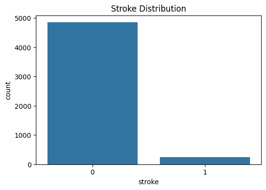

```python
# Class imbalance visualization
plt.figure(figsize=(6, 4))
sns.countplot(x='stroke', data=df)
plt.title("Stroke Distribution")
plt.show()
```

```python
# Now I need to separate the features from the target
X = df.drop(columns=['stroke'], axis = 1)
y = df['stroke']
```

### Feature importance

In a previous version on my project I decided to drop some features for which the correlation with stroke was appearing not linked. But then I saw that the model was not performing much better so I decided to keep all features. Because correlation shouldn't be the only reason to drop a feature—especially in classification problems since:

- Some features may not show a strong linear correlation with the target but still hold nonlinear or interaction effects.
- Some features may be important for fairness or interpretability, like gender or residence type, depending on the context.

# this is not an active part of code. just to show the investigation I realised on features importance drop_cols = [ 'gender_Other', 'work_type_children', 'Residence_type_Rural', 'Residence_type_Urban', 'smoking_status_never smoked' ] X = X.drop(columns=drop_cols)

```python
# Check class distribution (target variable)
print(y.value_counts())
print(f"Percentage of stroke cases: {y.mean()*100:.2f}%")
```

```
stroke
0    4848
1     249
Name: count, dtype: int64
Percentage of stroke cases: 4.89%
```

### Deal with imbalanced dataset

- Option 1: Upsampling minority class (resample)
- Option 2: SMOTE (Synthetic Minority Over-sampling Technique)
- Option 3: using balanced functionality that are available for some models.

I will use the 2nd and 3rd option because the resample technique is simpler but may overfit due to duplicate rows.

NB: The SMOTE technique will produce syntetic data. To use it all features must be numerical, and this was already done during the encoding phase.

```python
# I do the train / test split before SMOTE, since the SMOTE need to be done only to training set only to avoid data leakage and overfitting
X_train, X_test, y_train, y_test = train_test_split(X,y, test_size=0.2, stratify=y, random_state=25)

# SMOTE (Synthetic Minority Over-sampling Technique)
smote = SMOTE(random_state=25)
X_train_smo, y_train_smo = smote.fit_resample(X_train, y_train)
```

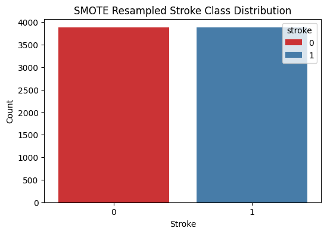

```python
# Plot new class distribution
plt.figure(figsize=(6, 4))
sns.countplot(x=y_train_smo, hue=y_train_smo, palette='Set1')
plt.title('SMOTE Resampled Stroke Class Distribution')
plt.xlabel('Stroke')
plt.ylabel('Count')
plt.show()
```

## Train and Evaluate on Original unbalanced Data

The RandomForestClassifier trained on the original (unbalanced) data almost never predicted any strokes during cross-validation.

That means:

- Precision and recall for stroke both became zero (or almost zero)
- Therefore F1 score also dropped to zero (or almost zero)

The classifier got overwhelmed by the dominant class (non-stroke) and defaults to predicting almost everything as non-stroke.

Even if the accuracy is 95% (very high) the recall and precision for the stroke case is zero, this means it predicted zero strokes.

The conclusion on this dataset is that it is not safe to be used the way it is (unbalanced).

Let's see the results using balancing techniques.

I will first create the model and cross-validate it and then retrain the model with the full train dataset for all the models I will use

```python
# Define the RF standard model
rf_unba_cv = RandomForestClassifier(random_state=25)

# Run 5-fold cross-validation using original (unbalanced) training data
scores = cross_val_score(rf_unba_cv, X_train, y_train, cv=5, scoring='f1')

# Show the results
print("Random Forest (Unbalanced) Cross-validated F1 scores:", scores)
print("Average F1 score:", scores.mean())
```

```
Random Forest (Unbalanced) Cross-validated F1 scores: [0.         0.04347826 0.         0.         0.        ]
Average F1 score: 0.008695652173913044
```

```python
rf_unba = RandomForestClassifier(random_state=25)
rf_unba.fit(X_train, y_train)
y_pred_rf_unba = rf_unba.predict(X_test)

print("=== Original unbalanced Data ===")
print("Confusion Matrix:\n", confusion_matrix(y_test, y_pred_rf_unba))
print("\nClassification Report:\n", classification_report(y_test, y_pred_rf_unba))
print("Accuracy Score:", accuracy_score(y_test, y_pred_rf_unba))
```

```
=== Original unbalanced Data ===
Confusion Matrix:
 [[970   0]
 [ 50   0]]

Classification Report:
               precision    recall  f1-score   support

           0       0.95      1.00      0.97       970
           1       0.00      0.00      0.00        50

    accuracy                           0.95      1020
   macro avg       0.48      0.50      0.49      1020
weighted avg       0.90      0.95      0.93      1020

Accuracy Score: 0.9509803921568627
```

## Train a Model on the Resampled Data

I will now train the model using balanced data.

#### SMOTE

The first technique is the SMOTE.

However the performance on the actual test set is poor for the positive (stroke) class. It completely fails to generalize to stroke cases. The model may have overfitted to the synthetic minority samples.

I will not proceed with this model

```python
#This model is a classic RF model that does not work well with unbalanced data so I will use the SMOTE once
rf_cv_smote = RandomForestClassifier(random_state=25)

# Run cross-validation using the SMOTE-resampled training set
scores = cross_val_score(rf_cv_smote, X_train_smo, y_train_smo, cv=5, scoring='f1')

print("Random Forest (SMOTE) Cross-validated F1 scores:", scores)
print("Average F1 score:", scores.mean())
```

```
Random Forest (SMOTE) Cross-validated F1 scores: [0.88011486 0.98346056 0.99422707 0.98726115 0.99423447]
Average F1 score: 0.9678596200055665
```

```python
rf_smote = RandomForestClassifier(random_state=25)
rf_smote.fit(X_train_smo, y_train_smo)
y_pred_smote = rf_smote.predict(X_test)

print("=== Smote balanced Data ===")
print("Confusion Matrix:\n", confusion_matrix(y_test, y_pred_smote))
print("\nClassification Report:\n", classification_report(y_test, y_pred_smote))
print("Accuracy Score:", accuracy_score(y_test, y_pred_smote))
```

```
=== Smote balanced Data ===
Confusion Matrix:
 [[959  11]
 [ 49   1]]

Classification Report:
               precision    recall  f1-score   support

           0       0.95      0.99      0.97       970
           1       0.08      0.02      0.03        50

    accuracy                           0.94      1020
   macro avg       0.52      0.50      0.50      1020
weighted avg       0.91      0.94      0.92      1020

Accuracy Score: 0.9411764705882353
```

#### Balanced Random Forest

In cv phase the low F1 scores (especially below 0.30) indicate that the model struggles to effectively identify the minority class (stroke cases), even with this model.

However, using the full train data there is a decent number of correctly identified stroke cases (TP = 33), but a high number of false positives (193), which may cause over-alerting.

This model is already better than the SMOTE one.

In real life it's better to create an over-alert than a under-alert.

```python
# This model does not need to use SMOTE data because it will balance the data automatically
brf_cv = BalancedRandomForestClassifier(random_state=25, n_estimators=300)

# Cross-validate on the training set (before fitting to all training data)
scores = cross_val_score(brf_cv, X_train, y_train, cv=5, scoring='f1')

print("Balanced RF Cross-Validated F1 Scores:", scores)
print("Average F1 Score:", scores.mean())
```

```
Balanced RF Cross-Validated F1 Scores: [0.26126126 0.25726141 0.25714286 0.22522523 0.26506024]
Average F1 Score: 0.2531901990763161
```

```python
# Full train data
brf = BalancedRandomForestClassifier(random_state=25, n_estimators=300) #does not improve over 300 n_estimators
brf.fit(X_train, y_train)
y_pred_brf = brf.predict(X_test)

from sklearn.metrics import classification_report, confusion_matrix
print(confusion_matrix(y_test, y_pred_brf))
print(classification_report(y_test, y_pred_brf))
```

```
[[777 193]
 [ 17  33]]
              precision    recall  f1-score   support

           0       0.98      0.80      0.88       970
           1       0.15      0.66      0.24        50

    accuracy                           0.79      1020
   macro avg       0.56      0.73      0.56      1020
weighted avg       0.94      0.79      0.85      1020
```

#### Fine Tune hyperparameters of balanced RF

I will now try to fine tune this model to check if it can perform better.

```python
param_dist = {
    'n_estimators': [100, 200, 300],
    'max_depth': [None, 10, 20, 30],
    'min_samples_split': [2, 5, 10],
    'min_samples_leaf': [1, 2, 4]
}

brf = BalancedRandomForestClassifier(random_state=25)

random_search_brf = RandomizedSearchCV(
    estimator=brf,
    param_distributions=param_dist,
    n_iter=20,
    scoring='f1',
    cv=5,
    n_jobs=-1,
    verbose=1
)

random_search_brf.fit(X_train, y_train)
best_brf = random_search_brf.best_estimator_

print("Best Parameters:", random_search_brf.best_params_)
```

```
Fitting 5 folds for each of 20 candidates, totalling 100 fits
Best Parameters: {'n_estimators': 300, 'min_samples_split': 2, 'min_samples_leaf': 1, 'max_depth': 20}
```

#### Threshold tuning to increase sensitivity to the minority class

Now, using the best parameters I will fine tune the best threshold.

With this fine tuning we can see that lowering the threshold the recall is increasing so we can catch more stroke cases, while the precisions will drop because a lot of non-stroke cases get misclassified.

With this model I would use a threshold of 0.5 (default) or 0.4, but not less than this because with lesser value the model will predict too much false positive stroke cases.

```python
# Train the model using bets parameters
brf = BalancedRandomForestClassifier(
    random_state=25,
    n_estimators=300,
    min_samples_split=2,
    min_samples_leaf=1,
    max_depth=20)
brf.fit(X_train, y_train)

# Get predicted probabilities for stroke cases
y_probs = brf.predict_proba(X_test)[:, 1]

# Define the thresholds to test
thresholds = [0.5, 0.4, 0.3, 0.2]

# Evaluate model at each threshold
for threshold in thresholds:
    y_pred_thresh = (y_probs >= threshold).astype(int)

    print(f"\n=== Threshold: {threshold} ===")
    print(confusion_matrix(y_test, y_pred_thresh))
    print(classification_report(y_test, y_pred_thresh, digits=3))
```

```
=== Threshold: 0.5 ===
[[776 194]
 [ 17  33]]
              precision    recall  f1-score   support

           0      0.979     0.800     0.880       970
           1      0.145     0.660     0.238        50

    accuracy                          0.793      1020
   macro avg      0.562     0.730     0.559      1020
weighted avg      0.938     0.793     0.849      1020


=== Threshold: 0.4 ===
[[698 272]
 [ 10  40]]
              precision    recall  f1-score   support

           0      0.986     0.720     0.832       970
           1      0.128     0.800     0.221        50

    accuracy                          0.724      1020
   macro avg      0.557     0.760     0.526      1020
weighted avg      0.944     0.724     0.802      1020


=== Threshold: 0.3 ===
[[606 364]
 [  5  45]]
              precision    recall  f1-score   support

           0      0.992     0.625     0.767       970
           1      0.110     0.900     0.196        50

    accuracy                          0.638      1020
   macro avg      0.551     0.762     0.481      1020
weighted avg      0.949     0.638     0.739      1020


=== Threshold: 0.2 ===
[[491 479]
 [  3  47]]
              precision    recall  f1-score   support

           0      0.994     0.506     0.671       970
           1      0.089     0.940     0.163        50

    accuracy                          0.527      1020
   macro avg      0.542     0.723     0.417      1020
weighted avg      0.950     0.527     0.646      1020
```

## ROC Curve and AUC Score and interpretation

The curve is well above the diagonal and the AUC score is good, that means the model is achieving a good balance of sensitivy and specificity.

```
ROC-AUC Score: 0.8178762886597937
```

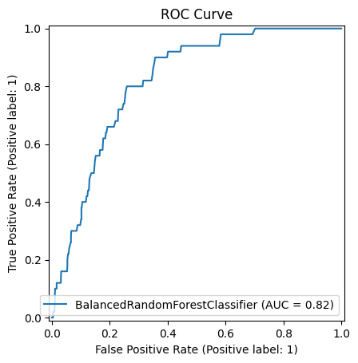

```python
print("ROC-AUC Score:", roc_auc_score(y_test, y_probs))

# Display ROC curve
RocCurveDisplay.from_estimator(brf, X_test, y_test)
plt.title("ROC Curve")
plt.show()
```

## Visualize the Confusion Matrix

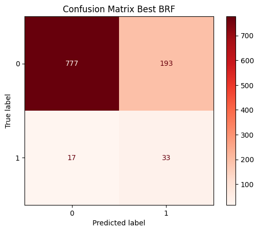

```python
ConfusionMatrixDisplay.from_estimator(brf, X_test, y_test, cmap='Reds')
plt.title("Confusion Matrix Best BRF")
plt.show()
```

## Try Other Models

#### Logistic Regression

The result are quite satisfying, similar to the RF Balanced, we have lack of precisions for false positive but the true stroke cases are well indentified.

```python
# Create pipeline: scaling + logistic regression. this because otherwise I will get a ConvergenceWarning
logi_pip = make_pipeline(StandardScaler(),
                               LogisticRegression(max_iter=1000, class_weight='balanced'))

# Train the model
logi_pip.fit(X_train, y_train)

# Predict
y_pred = logi_pip.predict(X_test)

# Evaluate
print("=== Evaluation Logistic Regression Model with Scaling ===")
print(confusion_matrix(y_test, y_pred))
print(classification_report(y_test, y_pred))
```

```
=== Evaluation Logistic Regression Model with Scaling ===
[[726 244]
 [ 15  35]]
              precision    recall  f1-score   support

           0       0.98      0.75      0.85       970
           1       0.13      0.70      0.21        50

    accuracy                           0.75      1020
   macro avg       0.55      0.72      0.53      1020
weighted avg       0.94      0.75      0.82      1020
```

#### XG Boost

I will use XG Boost because the Gradient Boosting does not perform well with unbalanced data.

Only 6 out of 50 stroke cases were correctly identified. The model is biased toward the majority class (non-stroke), despite the scale_pos_weight.

This model is not convincing.

```python
# Calculate scale_pos_weight = (number of negative samples / number of positive samples)
neg, pos = (y_train == 0).sum(), (y_train == 1).sum()
scale = neg / pos
print(f"scale_pos_weight: {scale:.2f}")

# Create pipeline
xgb_pip = make_pipeline(
    StandardScaler(),  # optional
    XGBClassifier(n_estimators=100,
                  scale_pos_weight=scale,
                  use_label_encoder=False,
                  eval_metric='logloss',
                  random_state=25)
)

# Train
xgb_pip.fit(X_train, y_train)

# Predict
y_pred_xgb = xgb_pip.predict(X_test)

# Evaluate
print("=== Evaluation XGBoost with class imbalance handling ===")
print(confusion_matrix(y_test, y_pred_xgb))
print(classification_report(y_test, y_pred_xgb))
```

```
scale_pos_weight: 19.49
=== Evaluation XGBoost with class imbalance handling ===
[[940  30]
 [ 44   6]]
              precision    recall  f1-score   support

           0       0.96      0.97      0.96       970
           1       0.17      0.12      0.14        50

    accuracy                           0.93      1020
   macro avg       0.56      0.54      0.55      1020
weighted avg       0.92      0.93      0.92      1020
```

#### Support vector machine

This model is performing quite similar to the RF Balanced and the Logistic Regression once

I will compare these three short listed models and choose one of them.

```python
# Create pipeline: scaling + SVM with balanced class weights
svm_pip = make_pipeline(StandardScaler(),
                        SVC(class_weight='balanced', probability=True))  # probability=True for ROC

# Train
svm_pip.fit(X_train, y_train)

# Predict
y_pred_svm = svm_pip.predict(X_test)

# Evaluate
print("=== Evaluation Balanced SVM with Scaling ===")
print(confusion_matrix(y_test, y_pred_svm))
print(classification_report(y_test, y_pred_svm))
```

```
=== Evaluation Balanced SVM with Scaling ===
[[753 217]
 [ 17  33]]
              precision    recall  f1-score   support

           0       0.98      0.78      0.87       970
           1       0.13      0.66      0.22        50

    accuracy                           0.77      1020
   macro avg       0.55      0.72      0.54      1020
weighted avg       0.94      0.77      0.83      1020
```

## Short Listed models comparison

### Confusion Matrices

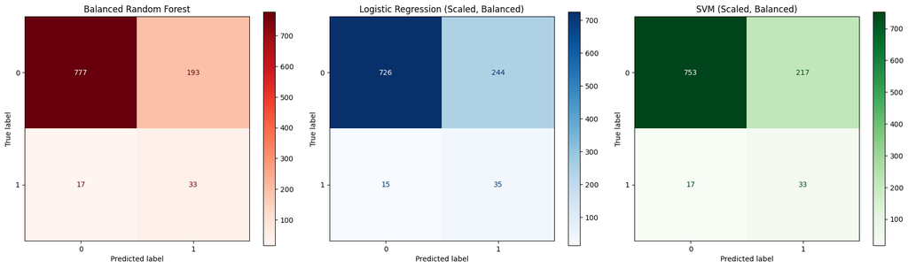

```python
# Confusion Matrices
fig, axs = plt.subplots(1, 3, figsize=(18, 5))

ConfusionMatrixDisplay.from_estimator(brf, X_test, y_test, cmap='Reds', ax=axs[0])
axs[0].set_title("Balanced Random Forest")

ConfusionMatrixDisplay.from_estimator(logi_pip, X_test, y_test, cmap='Blues', ax=axs[1])
axs[1].set_title("Logistic Regression (Scaled, Balanced)")

ConfusionMatrixDisplay.from_estimator(svm_pip, X_test, y_test, cmap='Greens', ax=axs[2])
axs[2].set_title("SVM (Scaled, Balanced)")

plt.tight_layout()
plt.show()
```

### ROC curve and AUC score

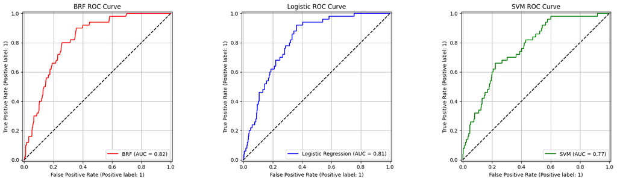

```python
# Get predicted probabilities
y_proba_brf = brf.predict_proba(X_test)[:, 1]
y_proba_logi = logi_pip.predict_proba(X_test)[:, 1]
y_proba_svm = svm_pip.predict_proba(X_test)[:, 1]

# Create 1 row, 3 columns of subplots
fig, axes = plt.subplots(1, 3, figsize=(18, 5))

# BRF ROC
RocCurveDisplay.from_predictions(
    y_test, y_proba_brf,
    name="BRF",
    color='red',
    ax=axes[0]
)
axes[0].plot([0, 1], [0, 1], 'k--')
axes[0].set_title("BRF ROC Curve")
axes[0].grid(True)

# Logistic ROC
RocCurveDisplay.from_predictions(
    y_test, y_proba_logi,
    name="Logistic Regression",
    color='blue',
    ax=axes[1]
)
axes[1].plot([0, 1], [0, 1], 'k--')
axes[1].set_title("Logistic ROC Curve")
axes[1].grid(True)

# SVM ROC
RocCurveDisplay.from_predictions(
    y_test, y_proba_svm,
    name="SVM",
    color='green',
    ax=axes[2]
)
axes[2].plot([0, 1], [0, 1], 'k--')
axes[2].set_title("SVM ROC Curve")
axes[2].grid(True)

# Adjust layout
plt.tight_layout()
plt.show()
```

# Conclusion

My conclusion is that I would recommend to use the Logistic regression model.

I think this is crucial in a medical diagnosis context. Missing a real stroke case (false negative) is much worse than predicting a stroke that isn’t there (false positive).

Moreover, logistic regression is:

- Easier to interpret
- Faster to train
- More transparent in medical applications

## Industrialize the model

To use thi model with new data this is the way to proceed.

```python
#industrialise the best model
import joblib

joblib.dump(logi_pip, 'stroke_prediction_model.pkl')

pipeline = joblib.load('stroke_prediction_model.pkl')
y_pred = pipeline.predict(new_data)
```